# Checkpoint 2: Building and Comparing ICU Mortality Models

Author

Haiyi Xiong

## AI-use statement

I used ChatGPT to help draft and debug R code, organize the modeling workflow, and improve the clarity of the written report. I ran the analyses in RStudio and checked the output tables, patient counts, cross-validation assignments, plots, and model predictions against the assignment requirements. AI assistance was useful for troubleshooting, but some generated code needed correction, including missing fold labels in saved prediction files. The limitation of this approach is that AI-generated code can contain errors, so I reviewed and revised the results rather than accepting suggestions without checking. I am responsible for the submitted analysis.

## Research question and approach

Can clinical measurements collected during the first 48 hours of an intensive care unit (ICU) stay predict in-hospital mortality? Using set-a only, I compare ridge-penalized logistic regression, a generalized additive model (GAM), and a random forest against the SAPS-I and SOFA clinical severity scores. Model discrimination is assessed by area under the receiver operating characteristic curve (AUROC), and probability accuracy by the Brier score. All model predictions used for evaluation are out-of-fold (OOF) predictions.

```r
# library
library(data.table)
library(dplyr)
library(tidyr)
library(knitr)
```

## 2.1 Modeling table

Each row represents one ICU stay identified by `RecordID`. The outcome is `In-hospital_death`, joined using the `RecordID` in `Outcomes-a.txt`. Patient characteristics are recorded at ICU time 00:00; time-varying predictors summarize observations from hours 0–48 only. The numeric missing-value code −1 is treated as missing, and non-positive height and weight values are excluded as implausible. For repeated clinical observations, I summarize rather than duplicate because repeated measurements describe the trajectory of care.

```r
# 2.1 Build the modeling table
# Uses set-a only
set.seed(707)

# 1. Define relative paths
data_dir <- "data"
out_dir <- "output"

dir.create(out_dir, showWarnings = FALSE)

# 2. Read the ICU records
files <- list.files(
  file.path(data_dir, "set-a"),
  pattern = "\\.txt$",
  full.names = TRUE
)

stopifnot(length(files) == 4000)

raw <- rbindlist(lapply(files, function(f) {
  x <- fread(f)

  stopifnot(
    all(c("Time", "Parameter", "Value") %in% names(x))
  )

  x[, RecordID := as.integer(
    tools::file_path_sans_ext(basename(f))
  )]

  x
}), fill = TRUE)

# 3. Convert measurement values to numeric
raw[, Value := as.numeric(Value)]

# Treat -1 as missing
raw[Value == -1, Value := NA_real_]

# 4. Convert time into ICU hours
time_parts <- tstrsplit(raw$Time, ":", fixed = TRUE)

raw[, ICU_hour :=
      as.numeric(time_parts[[1]]) +
      as.numeric(time_parts[[2]]) / 60]

# Restrict measurements to hours 0–48
raw <- raw[
  !is.na(ICU_hour) &
    ICU_hour >= 0 &
    ICU_hour <= 48
]

# 5. Extract static patient characteristics
static_vars <- c(
  "Age", "Gender", "Height", "ICUType", "Weight"
)

static <- raw[
  Time == "00:00" & Parameter %chin% static_vars,
  .(Value = Value[1]),
  by = .(RecordID, Parameter)
]

static <- dcast(
  static,
  RecordID ~ Parameter,
  value.var = "Value"
)

# Height and weight cannot be zero
static[!is.na(Height) & Height <= 0,
       Height := NA_real_]

static[!is.na(Weight) & Weight <= 0,
       Weight := NA_real_]

# 6. Extract time-varying measurements
measurements <- raw[
  !Parameter %chin% c(static_vars, "RecordID") &
    !is.na(Value)
]

setorder(
  measurements,
  RecordID,
  Parameter,
  ICU_hour
)

# 7. Summarize each measurement
summaries <- measurements[
  ,
  .(
    count = .N,
    first = Value[1],
    last = Value[.N],
    min = min(Value),
    max = max(Value),
    mean = mean(Value)
  ),
  by = .(RecordID, Parameter)
]

# 8. Convert long data to wide data
wide <- as_tibble(summaries) |>
  pivot_wider(
    id_cols = RecordID,
    names_from = Parameter,
    values_from = c(
      count, first, last, min, max, mean
    ),
    names_glue = "{Parameter}_{.value}"
  )

# 9. Replace missing measurement counts with zero
count_cols <- grep(
  "_count$",
  names(wide),
  value = TRUE
)

wide <- wide |>
  mutate(
    across(
      all_of(count_cols),
      ~ replace_na(.x, 0L)
    )
  )

# 10. Read outcome data
outcomes <- fread(
  file.path(data_dir, "Outcomes-a.txt")
)

stopifnot(
  nrow(outcomes) == 4000,
  anyDuplicated(outcomes$RecordID) == 0
)

# 11. Join predictors and outcomes
model_table <- as_tibble(static) |>
  left_join(wide, by = "RecordID") |>
  left_join(
    as_tibble(outcomes) |>
      select(
        RecordID,
        `In-hospital_death`,
        `SAPS-I`,
        SOFA
      ),
    by = "RecordID"
  ) |>
  rename(
    death = `In-hospital_death`
  ) |>
  mutate(
    death = as.integer(death),
    Gender = factor(Gender),
    ICUType = factor(ICUType)
  )

# 11-2

# Fix missing measurement counts after joining

model_table <- model_table |>
  mutate(
    across(
      ends_with("_count"),
      ~ tidyr::replace_na(.x, 0L)
    )
  )

# Verify that measurement counts contain no NA
stopifnot(
  sum(is.na(
    model_table |> select(ends_with("_count"))
  )) == 0
)

# 12. Keep benchmark scores separately
benchmarks <- model_table |>
  select(
    RecordID,
    death,
    `SAPS-I`,
    SOFA
  )

# SAPS-I and SOFA are not predictors
model_table <- model_table |>
  select(
    -`SAPS-I`,
    -SOFA
  )

# 13. Validate the dataset
stopifnot(
  nrow(model_table) == 4000,
  anyDuplicated(model_table$RecordID) == 0,
  !anyNA(model_table$death),
  all(model_table$death %in% c(0, 1))
)

# 14. Save intermediate datasets
write.csv(
  model_table,
  file.path(out_dir, "cp2_modeling_table.csv"),
  row.names = FALSE
)

write.csv(
  benchmarks,
  file.path(out_dir, "cp2_benchmarks.csv"),
  row.names = FALSE
)

# 15. Summary table for the report
model_summary <- data.frame(
  ICU_stays = nrow(model_table),
  Deaths = sum(model_table$death == 1),
  Mortality_percent = round(
    100 * mean(model_table$death == 1), 2
  ),
  Predictor_columns = ncol(model_table) - 2
)

knitr::kable(
  model_summary,
  caption = "Summary of the modeling dataset"
)
```

Summary of the modeling dataset

| ICU_stays | Deaths | Mortality_percent | Predictor_columns |
| --- | --- | --- | --- |
| 4000 | 554 | 13.85 | 221 |

```r
cat(
  "Unique RecordIDs:",
  dplyr::n_distinct(model_table$RecordID),
  "\n"
)
```

```
Unique RecordIDs: 4000
```

```r
cat(
  "Missing outcomes:",
  sum(is.na(model_table$death)),
  "\n"
)
```

```
Missing outcomes: 0
```

The dataset contains 4000 unique ICU stays, with 554 deaths (13.85%). A one-row-per-stay layout avoids multiple predictions for the same stay and supports direct comparison with SAPS-I and SOFA. The table below is derived exclusively from set-a, and no set-b or set-c files are read.

## 2.2 Predictors

I retain baseline age, gender, height, weight and ICU type; for each dynamic measurement I derive first, last, minimum, maximum, mean and measurement count. These summaries capture initial and recent physiology, extremes, typical levels and monitoring intensity. A measurement count of zero indicates that a measurement was never validly recorded in the observation window. `RecordID` identifies stays but is not a predictor. `Length_of_stay`, `Survival`, SAPS-I and SOFA are not used as features in the three machine learning models.

I prespecified a 98% predictor-missingness exclusion threshold to avoid training on almost entirely unobserved features. The threshold is evaluated within each training split, not using held-out samples; other missing values are handled by training-fold imputation.

```r
# 2.2 Predictor groups

baseline_vars <- c(
  "Age", "Gender", "Height", "Weight", "ICUType"
)

predictor_names <- setdiff(
  names(model_table),
  c("RecordID", "death")
)

predictor_dictionary <- tibble(
  Predictor = predictor_names
) |>
  mutate(
    Group = case_when(
      Predictor %in% baseline_vars ~ "Baseline",
      grepl("_first$", Predictor) ~ "First value",
      grepl("_last$", Predictor) ~ "Last value",
      grepl("_min$", Predictor) ~ "Minimum",
      grepl("_max$", Predictor) ~ "Maximum",
      grepl("_mean$", Predictor) ~ "Mean",
      grepl("_count$", Predictor) ~ "Measurement count",
      TRUE ~ "Other"
    ),
    Clinical_reason = case_when(
      Group == "Baseline" ~
        "Baseline patient risk and ICU admission context",
      Group == "First value" ~
        "Initial physiological condition",
      Group == "Last value" ~
        "Most recent physiological condition",
      Group == "Minimum" ~
        "Potentially important low measurements",
      Group == "Maximum" ~
        "Potentially important high measurements",
      Group == "Mean" ~
        "Average physiological condition",
      Group == "Measurement count" ~
        "Monitoring frequency and missingness information",
      TRUE ~ "Other clinical information"
    )
  )

predictor_summary <- predictor_dictionary |>
  count(
    Group,
    Clinical_reason,
    name = "Number_of_predictors"
  )

knitr::kable(
  predictor_summary,
  caption = "Predictor groups and clinical rationale"
)
```

Predictor groups and clinical rationale

| Group | Clinical_reason | Number_of_predictors |
| --- | --- | --- |
| Baseline | Baseline patient risk and ICU admission context | 5 |
| First value | Initial physiological condition | 36 |
| Last value | Most recent physiological condition | 36 |
| Maximum | Potentially important high measurements | 36 |
| Mean | Average physiological condition | 36 |
| Measurement count | Monitoring frequency and missingness information | 36 |
| Minimum | Potentially important low measurements | 36 |

```r
stopifnot(
  nrow(predictor_dictionary) == 221,
  !any(c(
    "Length_of_stay", "Survival",
    "SAPS-I", "SOFA", "In-hospital_death"
  ) %in% predictor_names)
)


# Missingness among measurement variables

missingness_summary <- model_table |>
  summarise(
    across(
      ends_with("_count"),
      ~ round(100 * mean(.x == 0), 1)
    )
  ) |>
  pivot_longer(
    cols = everything(),
    names_to = "Measurement",
    values_to = "Never_measured_percent"
  ) |>
  mutate(
    Measurement = sub(
      "_count$", "", Measurement
    )
  ) |>
  arrange(desc(Never_measured_percent))

# Display the 10 most frequently unmeasured variables
knitr::kable(
  head(missingness_summary, 10),
  caption = "Ten most frequently unmeasured variables"
)
```

Ten most frequently unmeasured variables

| Measurement | Never_measured_percent |
| --- | --- |
| TroponinI | 94.9 |
| Cholesterol | 92.4 |
| TroponinT | 78.4 |
| RespRate | 72.5 |
| Albumin | 59.6 |
| ALP | 57.8 |
| ALT | 57.0 |
| Bilirubin | 57.0 |
| AST | 56.9 |
| SaO2 | 55.2 |

The feature-group table lists 221 candidate predictors. The missingness table measures the fraction of stays with no valid observation for each parameter, not the proportion of missing hourly readings. For example, TroponinI is unmeasured in approximately 94.9% of stays. A zero measurement count retains this clinically relevant pattern. No variables are dropped using outcome information.

## 2.3 Cross-validation design

I use stratified five-fold cross-validation (CV), with mortality as the stratification variable and the ICU stay as the splitting unit. There is only one row per stay, so `RecordID` cannot appear simultaneously in training and validation. Exactly the same outer folds are used for all three fitted models and both clinical benchmarks. Predictor filtering, imputation, encoding and scaling are fitted only on training data, then applied to held-out data.

```r
# 2.3 Stratified 5-fold cross-validation
library(rsample)
library(recipes)
library(dplyr)
library(knitr)

set.seed(707)

# Convert outcome to a two-level factor
# This makes stratification explicit
cv_data <- model_table |>
  mutate(
    death = factor(
      death,
      levels = c(0, 1),
      labels = c("Survived", "Died")
    )
  )

# Each RecordID must represent exactly one stay
stopifnot(
  anyDuplicated(cv_data$RecordID) == 0
)

# Create five stratified folds
cv_folds <- vfold_cv(
  cv_data,
  v = 5,
  strata = death
)

# Save the folds for all three models
saveRDS(
  cv_folds,
  "output/cp2_folds.rds"
)

# Examine the balance of each fold
fold_summary <- bind_rows(
  lapply(seq_len(nrow(cv_folds)), function(i) {

    split_i <- cv_folds$splits[[i]]

    train_i <- rsample::analysis(split_i)
    valid_i <- rsample::assessment(split_i)

    tibble(
      Fold = cv_folds$id[[i]],
      Training_stays = nrow(train_i),
      Validation_stays = nrow(valid_i),
      Training_deaths = sum(train_i$death == "Died"),
      Validation_deaths = sum(valid_i$death == "Died"),
      Validation_death_pct = round(
        100 * mean(valid_i$death == "Died"), 2
      ),
      Overlapping_IDs = length(
        intersect(
          train_i$RecordID,
          valid_i$RecordID
        )
      )
    )
  })
)

knitr::kable(
  fold_summary,
  caption = "Stratified five-fold cross-validation design"
)
```

Stratified five-fold cross-validation design

| Fold | Training_stays | Validation_stays | Training_deaths | Validation_deaths | Validation_death_pct | Overlapping_IDs |
| --- | --- | --- | --- | --- | --- | --- |
| Fold1 | 3199 | 801 | 443 | 111 | 13.86 | 0 |
| Fold2 | 3200 | 800 | 443 | 111 | 13.88 | 0 |
| Fold3 | 3200 | 800 | 443 | 111 | 13.88 | 0 |
| Fold4 | 3200 | 800 | 443 | 111 | 13.88 | 0 |
| Fold5 | 3201 | 799 | 444 | 110 | 13.77 | 0 |

```r
# Validation checks
stopifnot(
  nrow(fold_summary) == 5,
  all(fold_summary$Overlapping_IDs == 0),
  sum(fold_summary$Validation_stays) == 4000,
  sum(fold_summary$Validation_deaths) == 554
)

# Every patient must appear in validation exactly once
validation_ids <- unlist(
  lapply(cv_folds$splits, function(s) {
    rsample::assessment(s)$RecordID
  }),
  use.names = FALSE
)

stopifnot(
  anyDuplicated(validation_ids) == 0,
  setequal(validation_ids, cv_data$RecordID)
)
```

The five held-out folds each contain approximately 800 stays and 110–111 deaths, with no overlap of `RecordID` between the analysis and assessment portions of a split. Using the saved fold object for every method rules out fold differences as an explanation for model-performance differences.

### Training-fold predictor exclusion audit

The following audit lists candidate predictors meeting the prespecified 98% missingness threshold in any *training* portion of the five outer folds. Actual preprocessing is still performed by the `recipes` workflow inside every training fold (and separately within inner folds for tuned models).

```r
missingness_drop_audit <- bind_rows(lapply(seq_len(nrow(cv_folds)), function(i) {
  train <- rsample::analysis(cv_folds$splits[[i]])
  pred_names <- setdiff(names(train), c("RecordID", "death"))
  missing_rate <- vapply(train[pred_names], function(x) mean(is.na(x)), numeric(1))
  keep_names <- names(missing_rate)[missing_rate >= 0.98]
  tibble(Fold = cv_folds$id[[i]], Predictor = keep_names,
         Training_missing_percent = round(100 * missing_rate[keep_names], 2))
}))
if (nrow(missingness_drop_audit) == 0L) {
  knitr::kable(data.frame(Result = "None of the raw candidate predictors reached the 98% missingness threshold in outer training folds"),
               caption = "Training-fold missingness screening")
} else {
  knitr::kable(missingness_drop_audit,
               caption = "Candidate predictors meeting the missingness exclusion threshold")
}
```

Training-fold missingness screening

| Result |
| --- |
| None of the raw candidate predictors reached the 98% missingness threshold in outer training folds |

### Preprocessing check on Fold 1

```r
# Test preprocessing using Fold 1 only

train_fold1 <- rsample::analysis(
  cv_folds$splits[[1]]
)

valid_fold1 <- rsample::assessment(
  cv_folds$splits[[1]]
)

# Specify preprocessing steps
recipe_logistic <- recipe(
  death ~ .,
  data = train_fold1
) |>
  update_role(
    RecordID,
    new_role = "ID"
  ) |>
  step_filter_missing(
    all_predictors(),
    threshold = 0.98
  ) |>
  step_impute_median(
    all_numeric_predictors()
  ) |>
  step_impute_mode(
    all_nominal_predictors()
  ) |>
  step_dummy(
    all_nominal_predictors()
  ) |>
  step_zv(
    all_predictors()
  ) |>
  step_normalize(
    all_numeric_predictors()
  )

# Learn preprocessing parameters using training data only
trained_recipe <- prep(
  recipe_logistic,
  training = train_fold1
)

# Apply the same preprocessing to both datasets
train_processed <- bake(
  trained_recipe,
  new_data = train_fold1
)

valid_processed <- bake(
  trained_recipe,
  new_data = valid_fold1
)

# Check validation predictors
valid_predictors <- valid_processed |>
  select(
    -any_of(c("RecordID", "death"))
  )

preprocessing_check <- data.frame(
  Training_rows = nrow(train_processed),
  Validation_rows = nrow(valid_processed),
  Processed_predictors = ncol(valid_predictors),
  Missing_predictor_values = sum(
    is.na(valid_predictors)
  )
)

knitr::kable(
  preprocessing_check,
  caption = "Preprocessing validation for Fold 1"
)
```

Preprocessing validation for Fold 1

| Training_rows | Validation_rows | Processed_predictors | Missing_predictor_values |
| --- | --- | --- | --- |
| 3199 | 801 | 218 | 0 |

```r
stopifnot(
  sum(is.na(valid_predictors)) == 0
)
```

## 2.4 Model 1: ridge logistic regression

Ridge (L2) penalization was selected because many first/last/minimum/maximum/mean summaries of the same clinical measure are strongly correlated. Ridge shrinks the coefficients without automatically discarding correlated predictors. Each outer training fold contains a separate stratified three-fold tuning procedure to select the penalty by log loss; external folds are used only to estimate performance. Numerical predictors are normalized before fitting so coefficient magnitudes are on a common scale.

```r
# 2.4A Ridge logistic regression with nested CV

library(tidymodels)
library(glmnet)

# Candidate regularization strengths
penalty_grid <- tibble(
  penalty = 10^seq(-4, 1, length.out = 12)
)

# Ridge logistic regression specification
ridge_spec <- logistic_reg(
  penalty = tune(),
  mixture = 0
) |>
  set_engine("glmnet", standardize = FALSE) |>
  set_mode("classification")

# Store out-of-fold predictions
ridge_results <- vector(
  "list",
  length = nrow(cv_folds)
)

# Outer cross-validation loop
for (i in seq_len(nrow(cv_folds))) {

  cat("Fitting outer fold", i, "of 5\n")

  outer_split <- cv_folds$splits[[i]]

  outer_train <- rsample::analysis(outer_split)
  outer_valid <- rsample::assessment(outer_split)

  # Inner CV uses only the outer training set
  set.seed(707 + i)

  inner_folds <- rsample::vfold_cv(
    outer_train,
    v = 3,
    strata = death
  )

  # Define preprocessing
  # Each inner training fold fits its own recipe
  ridge_recipe <- recipe(
    death ~ .,
    data = outer_train
  ) |>
    update_role(
      RecordID,
      new_role = "ID"
    ) |>
    step_filter_missing(
      all_predictors(),
      threshold = 0.98
    ) |>
    step_impute_median(
      all_numeric_predictors()
    ) |>
    step_impute_mode(
      all_nominal_predictors()
    ) |>
    step_dummy(
      all_nominal_predictors()
    ) |>
    step_zv(
      all_predictors()
    ) |>
    step_normalize(
      all_numeric_predictors()
    )

  # Combine model and preprocessing
  ridge_workflow <- workflow() |>
    add_recipe(ridge_recipe) |>
    add_model(ridge_spec)

  # Tune penalty using inner CV
  tuned <- tune_grid(
    ridge_workflow,
    resamples = inner_folds,
    grid = penalty_grid,
    metrics = metric_set(mn_log_loss),
    control = control_grid(
      save_pred = FALSE
    )
  )

  # Select penalty with lowest log loss
  best_penalty <- select_best(
    tuned,
    metric = "mn_log_loss"
  )

  # Fit on the complete outer training set
  final_workflow <- finalize_workflow(
    ridge_workflow,
    best_penalty
  )

  outer_fit <- fit(
    final_workflow,
    data = outer_train
  )

  # Predict death probability in held-out fold
  predicted_prob <- predict(
    outer_fit,
    new_data = outer_valid,
    type = "prob"
  )

  ridge_results[[i]] <- tibble(
    RecordID = outer_valid$RecordID,
    Fold = cv_folds$id[[i]],
    truth = outer_valid$death,
    p_death = predicted_prob$.pred_Died,
    penalty = best_penalty$penalty
  )
}
```

```
Fitting outer fold 1 of 5
Fitting outer fold 2 of 5
Fitting outer fold 3 of 5
Fitting outer fold 4 of 5
Fitting outer fold 5 of 5
```

```r
# Combine predictions from all five folds
ridge_oof <- bind_rows(ridge_results)

# Every stay should have one out-of-fold prediction
stopifnot(
  nrow(ridge_oof) == 4000,
  anyDuplicated(ridge_oof$RecordID) == 0,
  !anyNA(ridge_oof$p_death),
  all(ridge_oof$p_death >= 0),
  all(ridge_oof$p_death <= 1)
)

# Calculate AUROC for each fold
ridge_fold_auc <- ridge_oof |>
  group_by(Fold) |>
  summarise(
    N = n(),
    Deaths = sum(truth == "Died"),
    Best_penalty = first(penalty),
    AUROC = yardstick::roc_auc_vec(
      truth = truth,
      estimate = p_death,
      event_level = "second"
    ),
    Brier_score = mean(
      (p_death - as.integer(truth == "Died"))^2
    ),
    .groups = "drop"
  )

knitr::kable(
  ridge_fold_auc,
  digits = 4,
  caption = "Ridge logistic regression performance by fold"
)
```

Ridge logistic regression performance by fold

| Fold | N | Deaths | Best_penalty | AUROC | Brier_score |
| --- | --- | --- | --- | --- | --- |
| Fold1 | 801 | 111 | 0.0534 | 0.8129 | 0.0994 |
| Fold2 | 800 | 111 | 0.0534 | 0.8714 | 0.0870 |
| Fold3 | 800 | 111 | 0.4329 | 0.8031 | 0.1002 |
| Fold4 | 800 | 111 | 0.0534 | 0.8379 | 0.0981 |
| Fold5 | 799 | 110 | 0.0534 | 0.8427 | 0.0854 |

```r
# Summarize cross-validation performance
ridge_cv_summary <- ridge_fold_auc |>
  summarise(
    Mean_AUROC = mean(AUROC),
    SD_AUROC = sd(AUROC),
    Mean_Brier = mean(Brier_score)
  )

knitr::kable(
  ridge_cv_summary,
  digits = 4,
  caption = "Ridge logistic regression CV summary"
)
```

Ridge logistic regression CV summary

| Mean_AUROC | SD_AUROC | Mean_Brier |
| --- | --- | --- |
| 0.8336 | 0.0269 | 0.094 |

```r
# Save out-of-fold predictions
write.csv(
  ridge_oof |>
    mutate(
      death = as.integer(truth == "Died")
    ) |>
    select(
      RecordID,
      Fold,
      death,
      p_death,
      penalty
    ),
  "output/cp2_model1_ridge_oof.csv",
  row.names = FALSE
)

cat("Model 1 nested CV complete.\n")
```

```
Model 1 nested CV complete.
```

Ridge achieves a mean outer-fold AUROC of 0.8336 (SD 0.0269) and a mean Brier score of 0.0940. The fold-specific selected penalties show how regularization depends on the training sample. These estimates come from patients not used in the corresponding outer-fold model fitting.

### Refit ridge on all set-a stays and inspect coefficients

#### Final ridge tuning and refitting

```r
# 2.4B Refit Ridge on all set-a data

set.seed(1707)

# Define preprocessing for the full dataset
full_ridge_recipe <- recipe(
  death ~ .,
  data = cv_data
) |>
  update_role(
    RecordID,
    new_role = "ID"
  ) |>
  step_filter_missing(
    all_predictors(),
    threshold = 0.98
  ) |>
  step_impute_median(
    all_numeric_predictors()
  ) |>
  step_impute_mode(
    all_nominal_predictors()
  ) |>
  step_dummy(
    all_nominal_predictors()
  ) |>
  step_zv(
    all_predictors()
  ) |>
  step_normalize(
    all_numeric_predictors()
  )

# Model + recipe
full_ridge_workflow <- workflow() |>
  add_recipe(full_ridge_recipe) |>
  add_model(ridge_spec)

# Tune on all set-a using CV
# This is for final refitting, not for reporting new test performance
full_ridge_tuning <- tune_grid(
  full_ridge_workflow,
  resamples = cv_folds,
  grid = penalty_grid,
  metrics = metric_set(mn_log_loss),
  control = control_grid(
    save_pred = FALSE
  )
)

# Choose the best penalty
full_best_penalty <- select_best(
  full_ridge_tuning,
  metric = "mn_log_loss"
)

# Show best candidates
tuning_table <- collect_metrics(
  full_ridge_tuning
) |>
  filter(.metric == "mn_log_loss") |>
  arrange(mean) |>
  select(penalty, mean, std_err) |>
  head(5)

knitr::kable(
  tuning_table,
  digits = 5,
  caption = "Best Ridge penalty candidates"
)
```

Best Ridge penalty candidates

| penalty | mean | std_err |
| --- | --- | --- |
| 0.05337 | 0.30725 | 0.00825 |
| 0.01874 | 0.30856 | 0.00887 |
| 0.00010 | 0.31096 | 0.00901 |
| 0.00028 | 0.31096 | 0.00901 |
| 0.00081 | 0.31096 | 0.00901 |

```r
# Finalize and fit on all 4000 stays
ridge_final_workflow <- finalize_workflow(
  full_ridge_workflow,
  full_best_penalty
)

ridge_full_fit <- fit(
  ridge_final_workflow,
  data = cv_data
)

# Save fitted workflow including preprocessing
saveRDS(
  ridge_full_fit,
  "output/cp2_model1_ridge.rds"
)

cat(
  "Final Ridge penalty:",
  full_best_penalty$penalty,
  "\n"
)
```

```
Final Ridge penalty: 0.05336699
```

#### Standardized ridge coefficients

```r
# Extract Ridge coefficients at the selected penalty

ridge_coefficients <- ridge_full_fit |>
  workflows::extract_fit_parsnip() |>
  broom::tidy() |>
  filter(term != "(Intercept)") |>
  mutate(
    Absolute_coefficient = abs(estimate),
    Direction = if_else(
      estimate > 0,
      "Positive",
      "Negative"
    )
  ) |>
  arrange(desc(Absolute_coefficient))

# Save all coefficients
write.csv(
  ridge_coefficients,
  "output/cp2_model1_ridge_coefficients.csv",
  row.names = FALSE
)

# Display the 20 largest absolute coefficients
top20_coefficients <- ridge_coefficients |>
  slice_head(n = 20)

knitr::kable(
  top20_coefficients,
  digits = 4,
  caption = "Twenty largest standardized Ridge coefficients"
)
```

Twenty largest standardized Ridge coefficients

| term | estimate | penalty | Absolute_coefficient | Direction |
| --- | --- | --- | --- | --- |
| GCS_last | -0.3513 | 0.0534 | 0.3513 | Negative |
| Age | 0.2384 | 0.0534 | 0.2384 | Positive |
| GCS_max | -0.1902 | 0.0534 | 0.1902 | Negative |
| GCS_mean | -0.1617 | 0.0534 | 0.1617 | Negative |
| RespRate_count | -0.1243 | 0.0534 | 0.1243 | Negative |
| Temp_mean | -0.1234 | 0.0534 | 0.1234 | Negative |
| Weight | -0.1129 | 0.0534 | 0.1129 | Negative |
| ICUType_X2 | -0.1106 | 0.0534 | 0.1106 | Negative |
| BUN_last | 0.1062 | 0.0534 | 0.1062 | Positive |
| Glucose_last | 0.1035 | 0.0534 | 0.1035 | Positive |
| Urine_count | -0.0993 | 0.0534 | 0.0993 | Negative |
| GCS_count | 0.0952 | 0.0534 | 0.0952 | Positive |
| BUN_min | 0.0908 | 0.0534 | 0.0908 | Positive |
| HCT_count | -0.0881 | 0.0534 | 0.0881 | Negative |
| Temp_count | -0.0858 | 0.0534 | 0.0858 | Negative |
| GCS_first | 0.0830 | 0.0534 | 0.0830 | Positive |
| Na_count | 0.0808 | 0.0534 | 0.0808 | Positive |
| HR_max | 0.0771 | 0.0534 | 0.0771 | Positive |
| Na_first | -0.0760 | 0.0534 | 0.0760 | Negative |
| Temp_min | 0.0740 | 0.0534 | 0.0740 | Positive |

#### Ridge coefficient plot

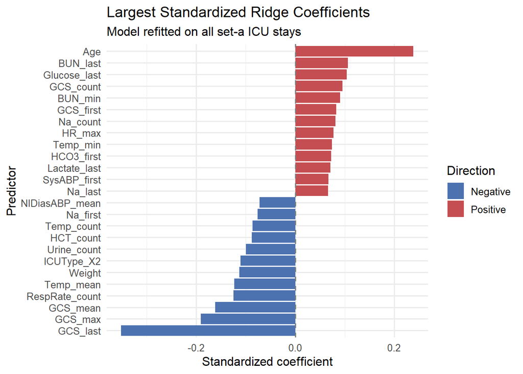

```r
# Plot the 25 largest standardized coefficients

top25_coefficients <- ridge_coefficients |>
  slice_head(n = 25) |>
  mutate(
    term = reorder(term, estimate)
  )

ridge_coef_plot <- ggplot(
  top25_coefficients,
  aes(
    x = term,
    y = estimate,
    fill = Direction
  )
) +
  geom_col() +
  coord_flip() +
  geom_hline(
    yintercept = 0,
    linetype = "dashed",
    color = "gray50"
  ) +
  scale_fill_manual(
    values = c(
      "Positive" = "#C44E52",
      "Negative" = "#4C72B0"
    )
  ) +
  labs(
    title = "Largest Standardized Ridge Coefficients",
    subtitle = "Model refitted on all set-a ICU stays",
    x = "Predictor",
    y = "Standardized coefficient",
    fill = "Direction"
  ) +
  theme_minimal(base_size = 12)

print(ridge_coef_plot)
```

```r
ggsave(
  filename = "output/cp2_ridge_coefficients_top25.png",
  plot = ridge_coef_plot,
  width = 10,
  height = 8,
  dpi = 300
)
```

**Figure interpretation.** The largest standardized ridge associations include lower fitted mortality log odds for higher last Glasgow Coma Scale (GCS) readings, and higher log odds for older age, elevated last blood urea nitrogen (BUN) and elevated last glucose. Multiple GCS and BUN summaries are correlated; individual coefficient signs and sizes are not independent causal effects. The coefficients are shown on a common standardized scale.

## 2.5 Model 2: generalized additive model

The logistic GAM uses 15 clinically interpretable predictors describing age, neurological status, kidney function, glucose, circulation, temperature, body size and measurement intensity. Smooth terms are fitted for age, last blood urea nitrogen (BUN), last glucose, maximum heart rate and mean temperature; remaining predictors are linear or categorical. Each spline has a fixed basis dimension of four, and the smoothing parameters are estimated using restricted maximum likelihood (REML) within training data. Since the GAM feature set was informed by model exploration on set-a, its cross-validation performance should be regarded as an internal, potentially somewhat optimistic comparison rather than an independent validation.

```r
# 2.5A GAM cross-validation

library(mgcv)
library(recipes)
library(dplyr)
library(yardstick)

# Select predictors based on clinical relevance
# and the Ridge model results

gam_smooth <- c(
  "Age",
  "BUN_last",
  "Glucose_last",
  "HR_max",
  "Temp_mean"
)

gam_linear <- c(
  "GCS_last",
  "Weight",
  "RespRate_count",
  "Urine_count",
  "GCS_count",
  "Na_first",
  "SysABP_min",
  "WBC_mean",
  "ICUType",
  "Gender"
)

gam_predictors <- c(
  gam_smooth,
  gam_linear
)

stopifnot(
  length(gam_predictors) == 15,
  all(gam_predictors %in% names(cv_data))
)

# Construct GAM formula
smooth_terms <- paste0(
  "s(", gam_smooth, ", bs = 'cr', k = 4)"
)

gam_formula <- reformulate(
  c(smooth_terms, gam_linear),
  response = "death"
)

print(gam_formula)
```

```
death ~ s(Age, bs = "cr", k = 4) + s(BUN_last, bs = "cr", k = 4) +
    s(Glucose_last, bs = "cr", k = 4) + s(HR_max, bs = "cr",
    k = 4) + s(Temp_mean, bs = "cr", k = 4) + GCS_last + Weight +
    RespRate_count + Urine_count + GCS_count + Na_first + SysABP_min +
    WBC_mean + ICUType + Gender
```

```r
# Keep identical predictor processing in each fold
prepare_gam_data <- function(dat) {
  dat |>
    dplyr::select(
      RecordID,
      death,
      dplyr::all_of(gam_predictors)
    ) |>
    dplyr::mutate(
      dplyr::across(
        dplyr::ends_with("_count"),
        log1p
      )
    )
}

# Store out-of-fold predictions
gam_results <- vector(
  "list",
  length = nrow(cv_folds)
)

for (i in seq_len(nrow(cv_folds))) {

  cat("Fitting GAM fold", i, "of 5\n")

  split_i <- cv_folds$splits[[i]]

  train_i <- prepare_gam_data(
    rsample::analysis(split_i)
  )

  valid_i <- prepare_gam_data(
    rsample::assessment(split_i)
  )

  # Imputation is learned from training data only
  gam_recipe <- recipe(
    death ~ .,
    data = train_i
  ) |>
    update_role(
      RecordID,
      new_role = "ID"
    ) |>
    step_impute_median(
      all_numeric_predictors()
    ) |>
    step_impute_mode(
      all_nominal_predictors()
    )

  gam_prep <- prep(
    gam_recipe,
    training = train_i
  )

  train_ready <- bake(
    gam_prep,
    new_data = train_i
  )

  valid_ready <- bake(
    gam_prep,
    new_data = valid_i
  )

  # Fit GAM; smoothing parameters estimated by REML
  gam_fit <- mgcv::gam(
    formula = gam_formula,
    data = train_ready,
    family = binomial(link = "logit"),
    method = "REML"
  )

  # Predict held-out mortality probabilities
  p_death <- as.numeric(
    predict(
      gam_fit,
      newdata = valid_ready,
      type = "response"
    )
  )

  gam_results[[i]] <- tibble(
    RecordID = valid_i$RecordID,
    Fold = cv_folds$id[[i]],
    truth = valid_i$death,
    p_death = p_death
  )
}
```

```
Fitting GAM fold 1 of 5
Fitting GAM fold 2 of 5
Fitting GAM fold 3 of 5
Fitting GAM fold 4 of 5
Fitting GAM fold 5 of 5
```

```r
# Combine all held-out predictions
gam_oof <- bind_rows(gam_results)

stopifnot(
  nrow(gam_oof) == 4000,
  anyDuplicated(gam_oof$RecordID) == 0,
  all(is.finite(gam_oof$p_death)),
  all(gam_oof$p_death >= 0),
  all(gam_oof$p_death <= 1)
)

# Evaluate each fold
gam_fold_auc <- gam_oof |>
  group_by(Fold) |>
  summarise(
    N = n(),
    Deaths = sum(truth == "Died"),
    AUROC = yardstick::roc_auc_vec(
      truth = truth,
      estimate = p_death,
      event_level = "second"
    ),
    Brier_score = mean(
      (p_death - as.integer(truth == "Died"))^2
    ),
    .groups = "drop"
  )

knitr::kable(
  gam_fold_auc,
  digits = 4,
  caption = "GAM performance by fold"
)
```

GAM performance by fold

| Fold | N | Deaths | AUROC | Brier_score |
| --- | --- | --- | --- | --- |
| Fold1 | 801 | 111 | 0.8071 | 0.0976 |
| Fold2 | 800 | 111 | 0.8733 | 0.0876 |
| Fold3 | 800 | 111 | 0.8323 | 0.0936 |
| Fold4 | 800 | 111 | 0.8234 | 0.0985 |
| Fold5 | 799 | 110 | 0.8218 | 0.0954 |

```r
gam_cv_summary <- gam_fold_auc |>
  summarise(
    Mean_AUROC = mean(AUROC),
    SD_AUROC = sd(AUROC),
    Mean_Brier = mean(Brier_score)
  )

knitr::kable(
  gam_cv_summary,
  digits = 4,
  caption = "GAM cross-validation summary"
)
```

GAM cross-validation summary

| Mean_AUROC | SD_AUROC | Mean_Brier |
| --- | --- | --- |
| 0.8316 | 0.025 | 0.0945 |

```r
# Save predictions for later model comparison
write.csv(
  gam_oof |>
    mutate(
      death = as.integer(truth == "Died")
    ) |>
    select(
      RecordID,
      Fold,
      death,
      p_death
    ),
  "output/cp2_model2_gam_oof.csv",
  row.names = FALSE
)
```

GAM achieves a mean outer-fold AUROC of 0.8316 (SD 0.0250) and a mean Brier score of 0.0945. These results are close to those for ridge, so the flexible smooths have not produced a clear discrimination advantage.

### Refit GAM on complete set-a

```r
# ============================================================
# STEP 2.5B — Fit final GAM using all set-a records
# ============================================================

library(dplyr)
library(recipes)
library(mgcv)
library(ggplot2)
library(tibble)
library(knitr)

dir.create("output", showWarnings = FALSE)

# Prepare complete modeling data
gam_full_data <- prepare_gam_data(cv_data)

# Define preprocessing recipe
gam_full_recipe <- recipe(
  death ~ .,
  data = gam_full_data
) |>
  update_role(RecordID, new_role = "ID") |>
  step_impute_median(all_numeric_predictors()) |>
  step_impute_mode(all_nominal_predictors())

# Fit preprocessing on all set-a records
gam_full_prep <- prep(
  gam_full_recipe,
  training = gam_full_data
)

gam_full_ready <- bake(
  gam_full_prep,
  new_data = gam_full_data
)

# Fit final GAM
gam_full_fit <- mgcv::gam(
  formula = gam_formula,
  data = gam_full_ready,
  family = binomial(link = "logit"),
  method = "REML"
)

# Inspect model
summary(gam_full_fit)
```

```
Family: binomial
Link function: logit

Formula:
death ~ s(Age, bs = "cr", k = 4) + s(BUN_last, bs = "cr", k = 4) +
    s(Glucose_last, bs = "cr", k = 4) + s(HR_max, bs = "cr",
    k = 4) + s(Temp_mean, bs = "cr", k = 4) + GCS_last + Weight +
    RespRate_count + Urine_count + GCS_count + Na_first + SysABP_min +
    WBC_mean + ICUType + Gender

Parametric coefficients:
                 Estimate Std. Error z value Pr(>|z|)
(Intercept)     5.4814757  1.5302919   3.582 0.000341 ***
GCS_last       -0.2332372  0.0154103 -15.135  < 2e-16 ***
Weight         -0.0078528  0.0026393  -2.975 0.002927 **
RespRate_count -0.0892065  0.0389261  -2.292 0.021924 *
Urine_count    -0.1776801  0.0782764  -2.270 0.023213 *
GCS_count       0.1359538  0.1381984   0.984 0.325234
Na_first       -0.0317238  0.0103388  -3.068 0.002152 **
SysABP_min      0.0002628  0.0018454   0.142 0.886758
WBC_mean        0.0151768  0.0066948   2.267 0.023393 *
ICUType2       -0.7465510  0.2225317  -3.355 0.000794 ***
ICUType3        0.4162976  0.1594633   2.611 0.009038 **
ICUType4        0.4237612  0.1847166   2.294 0.021784 *
Gender1        -0.0451625  0.1103363  -0.409 0.682307
---
Signif. codes:  0 '***' 0.001 '**' 0.01 '*' 0.05 '.' 0.1 ' ' 1

Approximate significance of smooth terms:
                  edf Ref.df Chi.sq  p-value
s(Age)          1.018  1.035  48.37  < 2e-16 ***
s(BUN_last)     2.559  2.865  85.40  < 2e-16 ***
s(Glucose_last) 1.004  1.008  10.67 0.001105 **
s(HR_max)       2.558  2.875  19.93 0.000301 ***
s(Temp_mean)    2.764  2.961  26.36 1.52e-05 ***
---
Signif. codes:  0 '***' 0.001 '**' 0.01 '*' 0.05 '.' 0.1 ' ' 1

R-sq.(adj) =  0.224   Deviance explained = 24.9%
-REML = 1248.7  Scale est. = 1         n = 4000
```

### GAM smooth-term summary

```r
gam_smooth_table <- as.data.frame(
  summary(gam_full_fit)$s.table
) |>
  tibble::rownames_to_column("Term")

knitr::kable(
  gam_smooth_table,
  digits = 3,
  caption = "Smooth terms in the final GAM"
)
```

Smooth terms in the final GAM

| Term | edf | Ref.df | Chi.sq | p-value |
| --- | --- | --- | --- | --- |
| s(Age) | 1.018 | 1.035 | 48.369 | 0.000 |
| s(BUN_last) | 2.559 | 2.865 | 85.402 | 0.000 |
| s(Glucose_last) | 1.004 | 1.008 | 10.666 | 0.001 |
| s(HR_max) | 2.558 | 2.875 | 19.935 | 0.000 |
| s(Temp_mean) | 2.764 | 2.961 | 26.364 | 0.000 |

Effective degrees of freedom (edf) near 1 indicate approximately linear fitted terms on the log-odds scale; an edf substantially above 1 indicates a more curved fitted shape. The smooth-term p-values test association, **not nonlinearity specifically**. Here age and last glucose are near-linear, while BUN, maximum heart rate and temperature have more visibly nonlinear shapes.

```r
saveRDS(
  list(
    model = gam_full_fit,
    preprocessing = gam_full_prep,
    predictors = gam_predictors,
    count_transform = "log1p"
  ),
  file = "output/cp2_model2_gam.rds"
)

file.exists("output/cp2_model2_gam.rds")
```

```
[1] TRUE
```

### GAM partial-effect plots

```r
# ============================================================
# Create a reference patient
# ============================================================

reference_patient <- gam_full_ready[
  1,
  gam_predictors,
  drop = FALSE
]

for (nm in gam_predictors) {

  x <- gam_full_ready[[nm]]

  if (is.factor(x)) {

    most_common <- names(
      which.max(table(x))
    )

    reference_patient[[nm]] <- factor(
      most_common,
      levels = levels(x)
    )

  } else {

    reference_patient[[nm]] <- median(
      x,
      na.rm = TRUE
    )

  }
}

reference_patient
```

```
# A tibble: 1 × 15
    Age BUN_last Glucose_last HR_max Temp_mean GCS_last Weight RespRate_count
  <dbl>    <dbl>        <dbl>  <dbl>     <dbl>    <dbl>  <dbl>          <dbl>
1    67       19          121    110      37.0       15   78.6              0
# ℹ 7 more variables: Urine_count <dbl>, GCS_count <dbl>, Na_first <dbl>,
#   SysABP_min <dbl>, WBC_mean <dbl>, ICUType <fct>, Gender <fct>
```

```r
# ============================================================
# Calculate adjusted odds-ratio curves
# ============================================================

gam_or_curve <- function(variable) {

  # Use the central 90% of observed values
  x_grid <- seq(
    quantile(
      gam_full_ready[[variable]],
      0.05,
      na.rm = TRUE
    ),
    quantile(
      gam_full_ready[[variable]],
      0.95,
      na.rm = TRUE
    ),
    length.out = 100
  )

  # Repeat reference patient for each grid value
  new_data <- reference_patient[
    rep(1, length(x_grid)),
    ,
    drop = FALSE
  ]

  new_data[[variable]] <- x_grid

  # Linear predictor matrices
  X_grid <- predict(
    gam_full_fit,
    newdata = new_data,
    type = "lpmatrix"
  )

  X_ref <- predict(
    gam_full_fit,
    newdata = reference_patient,
    type = "lpmatrix"
  )

  # Difference relative to the reference value
  X_diff <- sweep(
    X_grid,
    2,
    as.numeric(X_ref[1, ]),
    FUN = "-"
  )

  # Log odds ratio
  log_or <- as.numeric(
    X_diff %*% coef(gam_full_fit)
  )

  # Coefficient covariance matrix
  V <- vcov(
    gam_full_fit,
    unconditional = TRUE
  )

  # Standard error of the contrast
  se <- sqrt(
    pmax(
      rowSums((X_diff %*% V) * X_diff),
      0
    )
  )

  tibble(
    value = x_grid,
    OR = exp(log_or),
    lower = exp(log_or - 1.96 * se),
    upper = exp(log_or + 1.96 * se),
    reference = as.numeric(
      reference_patient[[variable]]
    )
  )
}
```

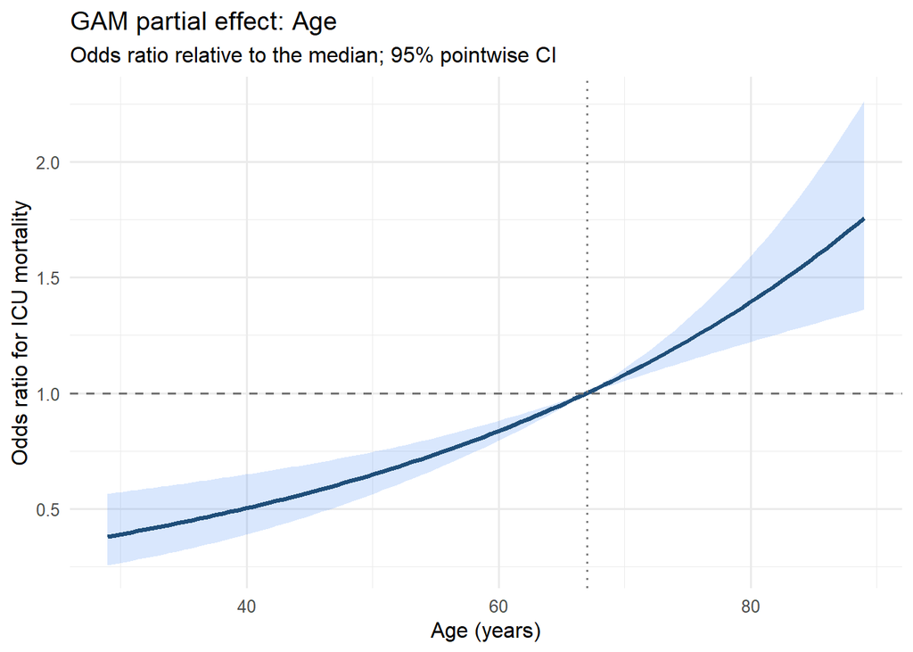

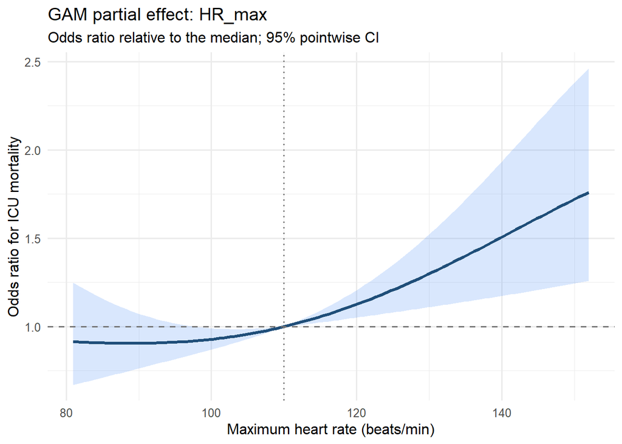

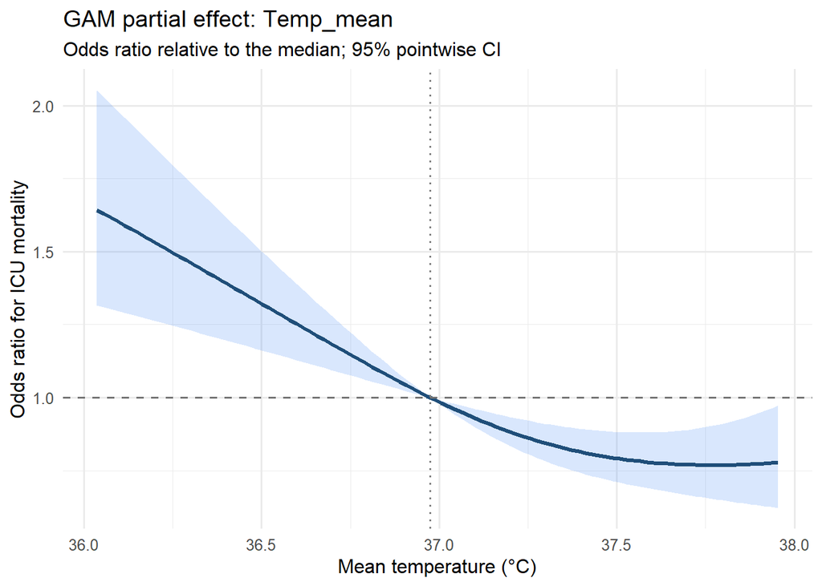

```r
# ============================================================
# Plot three GAM partial effects
# ============================================================

plot_variables <- c(
  "Age",
  "HR_max",
  "Temp_mean"
)

plot_labels <- c(
  Age = "Age (years)",
  HR_max = "Maximum heart rate (beats/min)",
  Temp_mean = "Mean temperature (°C)"
)

for (v in plot_variables) {

  curve_data <- gam_or_curve(v)

  p <- ggplot(
    curve_data,
    aes(x = value, y = OR)
  ) +

    geom_ribbon(
      aes(ymin = lower, ymax = upper),
      fill = "#4285F4",
      alpha = 0.20
    ) +

    geom_line(
      color = "#1F4E79",
      linewidth = 1.1
    ) +

    geom_hline(
      yintercept = 1,
      linetype = "dashed",
      color = "gray45"
    ) +

    geom_vline(
      xintercept = curve_data$reference[1],
      linetype = "dotted",
      color = "gray50"
    ) +

    labs(
      title = paste("GAM partial effect:", v),
      subtitle = "Odds ratio relative to the median; 95% pointwise CI",
      x = plot_labels[[v]],
      y = "Odds ratio for ICU mortality"
    ) +

    theme_minimal(base_size = 12)

  print(p)

  ggsave(
    filename = paste0(
      "output/cp2_gam_or_",
      v,
      ".png"
    ),
    plot = p,
    width = 7,
    height = 4.8,
    dpi = 300
  )
}
```

**Figure interpretation.** The age odds-ratio curve increases steadily relative to median age and is approximately linear on the log-odds scale. The maximum-heart-rate curve is relatively flat at lower values and rises at higher values. The mean-temperature curve indicates higher fitted mortality odds at lower temperatures and flattens toward higher temperatures. Shaded regions are 95% **pointwise** confidence intervals, and uncertainty widens at the ends of the observed ranges. These are adjusted associations rather than causal effects.

## 2.6 Model 3: random forest

I use a random forest of 300 trees to capture nonlinearities and interactions without specifying their functional forms. The number of candidate features per split (`mtry`: 10, 25 or 50) and minimum terminal-node size (`min_n`: 5 or 15) are tuned by three-fold log-loss cross-validation within each outer training fold. Missing values are imputed using each training split; predictors do not need standardization for a tree ensemble.

```r
library(tidymodels)
library(ranger)
library(dplyr)
library(tidyr)
library(knitr)

set.seed(707)

stopifnot(
  identical(
    levels(cv_data$death),
    c("Survived", "Died")
  )
)
```

```r
# ============================================================
# STEP 2.6A — Random Forest
# ============================================================

rf_recipe <- recipe(
  death ~ .,
  data = cv_data
) |>
  update_role(
    RecordID,
    new_role = "ID"
  ) |>
  step_filter_missing(
    threshold = 0.98
  ) |>
  step_impute_median(
    all_numeric_predictors()
  ) |>
  step_impute_mode(
    all_nominal_predictors()
  ) |>
  step_zv(
    all_predictors()
  )
```

```r
rf_spec <- rand_forest(
  trees = 300,
  mtry = tune(),
  min_n = tune()
) |>
  set_engine(
    "ranger",
    num.threads = 2,
    seed = 707
  ) |>
  set_mode("classification")

rf_workflow <- workflow() |>
  add_recipe(rf_recipe) |>
  add_model(rf_spec)

rf_grid <- tidyr::crossing(
  mtry = c(10L, 25L, 50L),
  min_n = c(5L, 15L)
)

rf_grid
```

```
# A tibble: 6 × 2
   mtry min_n
  <int> <int>
1    10     5
2    10    15
3    25     5
4    25    15
5    50     5
6    50    15
```

```r
# Store results for all five outer folds
rf_fold_results <- vector("list", 5)
rf_fold_predictions <- vector("list", 5)

for (i in seq_along(cv_folds$splits)) {

  cat("\n====================================\n")
  cat("Random Forest — Fold", i, "of 5\n")
  cat("====================================\n")

  # Outer training and validation sets
  outer_train <- rsample::analysis(
    cv_folds$splits[[i]]
  )

  outer_valid <- rsample::assessment(
    cv_folds$splits[[i]]
  )

  # Inner CV: training data only
  set.seed(707 + i)

  inner_folds <- rsample::vfold_cv(
    outer_train,
    v = 3,
    strata = death
  )

  # Tune parameters using inner CV
  rf_tuned <- tune::tune_grid(
    rf_workflow,
    resamples = inner_folds,
    grid = rf_grid,
    metrics = yardstick::metric_set(
      yardstick::mn_log_loss
    ),
    control = tune::control_grid(
      verbose = TRUE
    )
  )

  # Select best hyperparameters
  best_rf <- tune::select_best(
    rf_tuned,
    metric = "mn_log_loss"
  )

  # Finalize model for this outer fold
  final_rf_workflow <- tune::finalize_workflow(
    rf_workflow,
    best_rf
  )

  # Fit on outer training data only
  rf_fit <- fit(
    final_rf_workflow,
    data = outer_train
  )

  # Predict held-out outer validation set
  rf_prob <- predict(
    rf_fit,
    new_data = outer_valid,
    type = "prob"
  )

  rf_pred <- tibble(
    RecordID = outer_valid$RecordID,
    Fold = cv_folds$id[[i]],
    death = outer_valid$death,
    .pred_Died = rf_prob$.pred_Died
  )

  # Evaluation metrics
  fold_auroc <- yardstick::roc_auc(
    rf_pred,
    truth = death,
    .pred_Died,
    event_level = "second"
  )$.estimate

  fold_brier <- mean(
    (
      as.numeric(rf_pred$death == "Died") -
        rf_pred$.pred_Died
    )^2
  )

  rf_fold_results[[i]] <- tibble(
    Fold = paste0("Fold", i),
    N = nrow(outer_valid),
    Deaths = sum(outer_valid$death == "Died"),
    Best_mtry = best_rf$mtry,
    Best_min_n = best_rf$min_n,
    AUROC = fold_auroc,
    Brier_score = fold_brier
  )

  rf_fold_predictions[[i]] <- rf_pred

  # Save progress after every fold
  saveRDS(
    list(
      metrics = rf_fold_results,
      predictions = rf_fold_predictions
    ),
    "output/cp2_rf_progress.rds"
  )

  print(rf_fold_results[[i]])
}
```

```
====================================
Random Forest — Fold 1 of 5
====================================
```

```
# A tibble: 1 × 7
  Fold      N Deaths Best_mtry Best_min_n AUROC Brier_score
  <chr> <int>  <int>     <int>      <int> <dbl>       <dbl>
1 Fold1   801    111        50         15 0.839      0.0941

====================================
Random Forest — Fold 2 of 5
====================================
```

```
# A tibble: 1 × 7
  Fold      N Deaths Best_mtry Best_min_n AUROC Brier_score
  <chr> <int>  <int>     <int>      <int> <dbl>       <dbl>
1 Fold2   800    111        25          5 0.850      0.0922

====================================
Random Forest — Fold 3 of 5
====================================
```

```
# A tibble: 1 × 7
  Fold      N Deaths Best_mtry Best_min_n AUROC Brier_score
  <chr> <int>  <int>     <int>      <int> <dbl>       <dbl>
1 Fold3   800    111        25         15 0.828      0.0945

====================================
Random Forest — Fold 4 of 5
====================================
```

```
# A tibble: 1 × 7
  Fold      N Deaths Best_mtry Best_min_n AUROC Brier_score
  <chr> <int>  <int>     <int>      <int> <dbl>       <dbl>
1 Fold4   800    111        25          5 0.838      0.0936

====================================
Random Forest — Fold 5 of 5
====================================
```

```
# A tibble: 1 × 7
  Fold      N Deaths Best_mtry Best_min_n AUROC Brier_score
  <chr> <int>  <int>     <int>      <int> <dbl>       <dbl>
1 Fold5   799    110        25         15 0.849      0.0892
```

```r
rf_cv_results <- dplyr::bind_rows(
  rf_fold_results
)

rf_cv_summary <- tibble(
  Mean_AUROC = mean(rf_cv_results$AUROC),
  SD_AUROC = sd(rf_cv_results$AUROC),
  Mean_Brier = mean(rf_cv_results$Brier_score)
)

knitr::kable(
  rf_cv_results,
  digits = 4,
  caption = "Random Forest performance by fold"
)
```

Random Forest performance by fold

| Fold | N | Deaths | Best_mtry | Best_min_n | AUROC | Brier_score |
| --- | --- | --- | --- | --- | --- | --- |
| Fold1 | 801 | 111 | 50 | 15 | 0.8393 | 0.0941 |
| Fold2 | 800 | 111 | 25 | 5 | 0.8501 | 0.0922 |
| Fold3 | 800 | 111 | 25 | 15 | 0.8278 | 0.0945 |
| Fold4 | 800 | 111 | 25 | 5 | 0.8382 | 0.0936 |
| Fold5 | 799 | 110 | 25 | 15 | 0.8494 | 0.0892 |

```r
knitr::kable(
  rf_cv_summary,
  digits = 4,
  caption = "Random Forest cross-validation summary"
)
```

Random Forest cross-validation summary

| Mean_AUROC | SD_AUROC | Mean_Brier |
| --- | --- | --- |
| 0.8409 | 0.0092 | 0.0927 |

Random forest achieves a mean outer-fold AUROC of 0.8409 (SD 0.0092) and a mean Brier score of 0.0927. Performance is comparatively stable across the five validation folds. The tuning grid and the selected `mtry` and `min_n` for each fold are reported above.

```r
rf_oof <- dplyr::bind_rows(
  rf_fold_predictions
) |>
  arrange(RecordID)

stopifnot(
  nrow(rf_oof) == 4000,
  dplyr::n_distinct(rf_oof$RecordID) == 4000,
  !anyNA(rf_oof$.pred_Died)
)

write.csv(
  rf_oof,
  "output/cp2_model3_rf_oof.csv",
  row.names = FALSE
)

write.csv(
  rf_cv_results,
  "output/cp2_model3_rf_cv.csv",
  row.names = FALSE
)
```

### Tune random forest for final refitting

```r
# ============================================================
# STEP 2.6B — Final Random Forest
# ============================================================

set.seed(707)

# Tune using all 4,000 records
rf_full_tuned <- tune::tune_grid(
  rf_workflow,
  resamples = cv_folds,
  grid = rf_grid,
  metrics = yardstick::metric_set(
    yardstick::mn_log_loss
  ),
  control = tune::control_grid(
    verbose = TRUE
  )
)

# Display leading parameter combinations
tune::show_best(
  rf_full_tuned,
  metric = "mn_log_loss",
  n = 6
)
```

```
# A tibble: 6 × 8
   mtry min_n .metric     .estimator  mean     n std_err .config
  <int> <int> <chr>       <chr>      <dbl> <int>   <dbl> <chr>
1    50     5 mn_log_loss binary     0.302     5 0.00335 pre0_mod5_post0
2    50    15 mn_log_loss binary     0.303     5 0.00314 pre0_mod6_post0
3    25    15 mn_log_loss binary     0.303     5 0.00323 pre0_mod4_post0
4    25     5 mn_log_loss binary     0.304     5 0.00313 pre0_mod3_post0
5    10     5 mn_log_loss binary     0.306     5 0.00335 pre0_mod1_post0
6    10    15 mn_log_loss binary     0.307     5 0.00322 pre0_mod2_post0
```

```r
# Select final parameters
rf_best_final <- tune::select_best(
  rf_full_tuned,
  metric = "mn_log_loss"
)

print(rf_best_final)
```

```
# A tibble: 1 × 3
   mtry min_n .config
  <int> <int> <chr>
1    50     5 pre0_mod5_post0
```

### Final random forest fit

```r
rf_final_spec <- rand_forest(
  trees = 300,
  mtry = rf_best_final$mtry,
  min_n = rf_best_final$min_n
) |>
  set_engine(
    "ranger",
    importance = "permutation",
    num.threads = 2,
    seed = 707
  ) |>
  set_mode("classification")

rf_final_workflow <- workflow() |>
  add_recipe(rf_recipe) |>
  add_model(rf_final_spec)

set.seed(707)

rf_final_fit <- fit(
  rf_final_workflow,
  data = cv_data
)

saveRDS(
  rf_final_fit,
  file = "output/cp2_model3_rf.rds"
)

file.exists("output/cp2_model3_rf.rds")
```

```
[1] TRUE
```

### Permutation variable importance

```r
rf_engine <- workflows::extract_fit_engine(
  rf_final_fit
)

rf_importance <- tibble(
  Predictor = names(
    rf_engine$variable.importance
  ),
  Importance = as.numeric(
    rf_engine$variable.importance
  )
) |>
  arrange(desc(Importance))

rf_top20 <- rf_importance |>
  slice_head(n = 20)

knitr::kable(
  rf_top20,
  digits = 4,
  caption = "Twenty most important Random Forest predictors"
)
```

Twenty most important Random Forest predictors

| Predictor | Importance |
| --- | --- |
| GCS_last | 0.0116 |
| GCS_mean | 0.0074 |
| Urine_mean | 0.0070 |
| BUN_mean | 0.0068 |
| BUN_last | 0.0065 |
| GCS_max | 0.0040 |
| BUN_min | 0.0038 |
| BUN_max | 0.0035 |
| BUN_first | 0.0024 |
| HCO3_mean | 0.0017 |
| ALP_last | 0.0015 |
| Urine_max | 0.0014 |
| Creatinine_mean | 0.0012 |
| Albumin_mean | 0.0011 |
| Age | 0.0011 |
| ALP_mean | 0.0010 |
| Bilirubin_last | 0.0010 |
| Creatinine_first | 0.0010 |
| Temp_max | 0.0010 |
| ALP_min | 0.0010 |

```r
write.csv(
  rf_importance,
  "output/cp2_rf_variable_importance.csv",
  row.names = FALSE
)
```

### Random forest importance plot

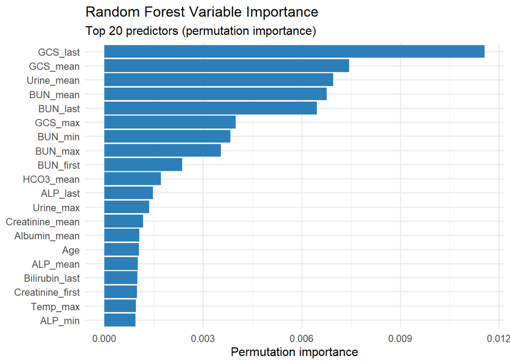

```r
rf_importance_plot <- rf_top20 |>
  mutate(
    Predictor = forcats::fct_reorder(
      Predictor,
      Importance
    )
  ) |>
  ggplot(
    aes(
      x = Importance,
      y = Predictor
    )
  ) +
  geom_col(
    fill = "#2C7FB8"
  ) +
  labs(
    title = "Random Forest Variable Importance",
    subtitle = "Top 20 predictors (permutation importance)",
    x = "Permutation importance",
    y = NULL
  ) +
  theme_minimal(base_size = 12)

print(rf_importance_plot)
```

```r
ggsave(
  "output/cp2_rf_variable_importance.png",
  plot = rf_importance_plot,
  width = 8,
  height = 6,
  dpi = 300
)
```

**Figure interpretation.** Permutation importance ranks last and mean GCS, mean urine output and several BUN summaries highly. These measurements summarize neurological status, urine output and renal function, respectively. Their permutation importance represents predictive contribution in this fitted forest, and can be shared or unstable across correlated predictors; it does not imply causality.

## 2.7 Comparison and final model selection

For a like-for-like comparison, SAPS-I and SOFA are each used as a **single-score** logistic risk predictor. The score-to-risk logistic calibration and any score imputation are fitted separately within each outer training fold. Thus benchmark Brier scores describe fold-wise calibrated scores, rather than raw ordinal severity scores. Their ROC rankings are compared using the same validation stays and five folds as the three machine learning models.

### 2.7.0 Reproducible SAPS-I and SOFA benchmark predictions

The outcomes file supplies SAPS-I and SOFA scores. Each is evaluated separately, without including the other score or any machine-learning features. Median score imputation and the one-predictor logistic calibration are estimated only on each outer training fold and then applied to the held-out fold. This step **creates** the benchmark OOF CSV rather than relying on a file generated manually in a previous RStudio session.

```r
# 2.7.0: Create benchmark predictions from set-a only
benchmark_scores <- c("SAPS-I", "SOFA")
benchmark_results <- vector("list", length(benchmark_scores) * nrow(cv_folds))
idx <- 0L

for (score_name in benchmark_scores) {
  for (i in seq_len(nrow(cv_folds))) {
    split_i <- cv_folds$splits[[i]]
    train_ids <- rsample::analysis(split_i)$RecordID
    valid_ids <- rsample::assessment(split_i)$RecordID

    train_b <- tibble(RecordID = train_ids) |>
      left_join(benchmarks, by = "RecordID")
    valid_b <- tibble(RecordID = valid_ids) |>
      left_join(benchmarks, by = "RecordID")

    # The original PhysioNet missing-value code is -1.
    train_score <- as.numeric(train_b[[score_name]])
    valid_score <- as.numeric(valid_b[[score_name]])
    train_score[!is.finite(train_score) | train_score == -1] <- NA_real_
    valid_score[!is.finite(valid_score) | valid_score == -1] <- NA_real_

    imputation_median <- median(train_score, na.rm = TRUE)
    stopifnot(is.finite(imputation_median))
    train_score[is.na(train_score)] <- imputation_median
    valid_score[is.na(valid_score)] <- imputation_median

    train_calibration <- data.frame(
      death = as.integer(train_b$death),
      score = train_score
    )
    valid_calibration <- data.frame(score = valid_score)

    calibrated_model <- glm(
      death ~ score,
      data = train_calibration,
      family = binomial(link = "logit")
    )
    predicted <- as.numeric(predict(
      calibrated_model,
      newdata = valid_calibration,
      type = "response"
    ))

    idx <- idx + 1L
    benchmark_results[[idx]] <- tibble(
      RecordID = valid_b$RecordID,
      Fold = cv_folds$id[[i]],
      death = as.integer(valid_b$death),
      p_death = predicted,
      Model = if (score_name == "SAPS-I") "SAPS_I" else "SOFA"
    )
  }
}

benchmark_oof <- bind_rows(benchmark_results)
stopifnot(
  nrow(benchmark_oof) == 8000,
  !anyDuplicated(benchmark_oof[c("RecordID", "Model")]),
  !anyNA(benchmark_oof$p_death),
  all(benchmark_oof$p_death >= 0 & benchmark_oof$p_death <= 1)
)
write.csv(
  benchmark_oof,
  "output/cp2_benchmark_oof.csv",
  row.names = FALSE
)

benchmark_fold_summary <- benchmark_oof |>
  mutate(truth = factor(death, levels = c(0, 1),
                        labels = c("Survived", "Died"))) |>
  group_by(Model, Fold) |>
  summarise(
    AUROC = yardstick::roc_auc_vec(truth, p_death,
                                   event_level = "second"),
    Brier_score = mean((p_death - death)^2),
    .groups = "drop"
  )
knitr::kable(
  benchmark_fold_summary |>
    group_by(Model) |>
    summarise(Mean_AUROC = mean(AUROC), SD_AUROC = sd(AUROC),
              Mean_Brier = mean(Brier_score), .groups = "drop"),
  digits = 4,
  caption = "Clinical score benchmarks (training-fold calibration)"
)
```

Clinical score benchmarks (training-fold calibration)

| Model | Mean_AUROC | SD_AUROC | Mean_Brier |
| --- | --- | --- | --- |
| SAPS_I | 0.6460 | 0.0248 | 0.1152 |
| SOFA | 0.6198 | 0.0361 | 0.1151 |

### 2.7.1 Fold reconstruction and integrity checks

```r
# ============================================================
# 2.7 Model Comparison and Final Model Selection
# ============================================================

library(dplyr)
library(tidyr)
library(ggplot2)
library(yardstick)
library(rsample)
library(knitr)

dir.create("output", showWarnings = FALSE)

# Load the original five-fold CV splits
cv_folds <- readRDS(
  "output/cp2_folds.rds"
)

# Reconstruct RecordID-to-Fold mapping
# Also recover the true outcome for validation
correct_fold_map <- bind_rows(
  lapply(seq_len(nrow(cv_folds)), function(i) {

    valid <- assessment(cv_folds$splits[[i]])

    tibble(
      RecordID = as.character(valid$RecordID),
      Correct_Fold = as.character(cv_folds$id[[i]]),
      Correct_death = as.integer(
        as.character(valid$death) %in% c("Died", "1")
      )
    )
  })
)

# Verify the saved CV splits
stopifnot(
  nrow(correct_fold_map) == 4000,
  n_distinct(correct_fold_map$RecordID) == 4000,
  !anyNA(correct_fold_map$Correct_Fold),
  sum(correct_fold_map$Correct_death) == 554
)

cat("Original five-fold mapping loaded successfully.\n")
```

```
Original five-fold mapping loaded successfully.
```

### 2.7.2 Load standardized OOF predictions

```r
# ============================================================
# Function: Read and standardize OOF predictions
# ============================================================

read_oof <- function(file, model_name = NULL) {

  dat <- read.csv(
    file,
    check.names = FALSE,
    stringsAsFactors = FALSE
  )

  if (!"RecordID" %in% names(dat)) {
    stop("Missing RecordID in: ", file)
  }

  # Identify probability column
  prob_options <- c(
    "p_death",
    ".pred_Died",
    "predicted_probability",
    "predicted_prob",
    "pred_prob",
    "probability",
    "prob",
    "p_hat",
    "pred_death"
  )

  prob_col <- intersect(
    prob_options,
    names(dat)
  )

  if (length(prob_col) == 0) {
    stop(
      "Probability column not found in: ", file,
      "\nAvailable columns: ",
      paste(names(dat), collapse = ", ")
    )
  }

  prob_col <- prob_col[1]

  # Identify outcome column
  outcome_options <- c(
    "death",
    "truth",
    "In-hospital_death"
  )

  outcome_col <- intersect(
    outcome_options,
    names(dat)
  )

  if (length(outcome_col) == 0) {
    stop(
      "Outcome column not found in: ", file,
      "\nAvailable columns: ",
      paste(names(dat), collapse = ", ")
    )
  }

  outcome_col <- outcome_col[1]

  # Standardize outcome to 0/1
  outcome_values <- as.character(
    dat[[outcome_col]]
  )

  death_numeric <- case_when(
    outcome_values %in% c("0", "Survived") ~ 0L,
    outcome_values %in% c("1", "Died") ~ 1L,
    TRUE ~ NA_integer_
  )

  # Standardize model names
  if (!is.null(model_name)) {

    model_values <- rep(
      model_name,
      nrow(dat)
    )

  } else {

    if (!"Model" %in% names(dat)) {
      stop("Missing Model column in: ", file)
    }

    model_values <- as.character(dat$Model)
  }

  model_values <- case_when(
    model_values %in% c(
      "SAPS_I", "SAPS-I", "SAPS I"
    ) ~ "SAPS-I",
    model_values == "SOFA" ~ "SOFA",
    TRUE ~ model_values
  )

  # Standardize data format
  result <- tibble(
    RecordID = as.character(dat$RecordID),
    death = death_numeric,
    p_death = as.numeric(dat[[prob_col]]),
    Model = model_values
  )

  # Add original Fold mapping
  result <- result |>
    left_join(
      correct_fold_map,
      by = "RecordID"
    )

  # Check original fold labels if they exist
  if ("Fold" %in% names(dat)) {

    existing_fold <- as.character(dat$Fold)

    inconsistent <- (
      !is.na(existing_fold) &
        nzchar(existing_fold) &
        (
          is.na(result$Correct_Fold) |
            existing_fold != result$Correct_Fold
        )
    )

    inconsistent[is.na(inconsistent)] <- TRUE

    if (any(inconsistent)) {
      stop(
        "Saved Fold labels disagree with original CV: ",
        file
      )
    }
  }

  # Verify observed outcomes
  stopifnot(
    !anyNA(result$death),
    !anyNA(result$Correct_death),
    all(result$death == result$Correct_death)
  )

  # Use verified original fold labels
  result <- result |>
    mutate(
      Fold = Correct_Fold
    ) |>
    select(
      RecordID,
      Fold,
      death,
      p_death,
      Model
    )

  # Validate predictions
  stopifnot(
    nrow(result) == 4000 ||
      (
        is.null(model_name) &&
          nrow(result) == 8000
      ),
    !anyNA(result$Fold),
    !anyNA(result$p_death),
    all(is.finite(result$p_death)),
    all(result$p_death >= 0),
    all(result$p_death <= 1)
  )

  return(result)
}
```

### 2.7.3 Merge the five prediction methods

```r
# ============================================================
# Read all five prediction methods
# ============================================================

ridge_pred <- read_oof(
  "output/cp2_model1_ridge_oof.csv",
  "Ridge"
)

gam_pred <- read_oof(
  "output/cp2_model2_gam_oof.csv",
  "GAM"
)

rf_pred <- read_oof(
  "output/cp2_model3_rf_oof.csv",
  "Random Forest"
)

benchmark_pred <- read_oof(
  "output/cp2_benchmark_oof.csv"
)

# Combine predictions
all_oof <- bind_rows(
  ridge_pred,
  gam_pred,
  rf_pred,
  benchmark_pred
)

# Define consistent model order
model_order <- c(
  "Random Forest",
  "Ridge",
  "GAM",
  "SAPS-I",
  "SOFA"
)

all_oof <- all_oof |>
  mutate(
    Model = factor(
      Model,
      levels = model_order
    ),
    truth = factor(
      death,
      levels = c(0, 1),
      labels = c("Survived", "Died")
    )
  )

# Check number of predictions
prediction_counts <- all_oof |>
  count(Model)

knitr::kable(
  prediction_counts,
  caption = "Number of out-of-fold predictions"
)
```

Number of out-of-fold predictions

| Model | n |
| --- | --- |
| Random Forest | 4000 |
| Ridge | 4000 |
| GAM | 4000 |
| SAPS-I | 4000 |
| SOFA | 4000 |

```r
# Verify all patients have five predictions
patient_check <- all_oof |>
  group_by(RecordID) |>
  summarise(
    n_predictions = n(),
    n_models = n_distinct(Model),
    n_folds = n_distinct(Fold),
    n_outcomes = n_distinct(death),
    .groups = "drop"
  )

stopifnot(
  nrow(all_oof) == 20000,
  nrow(patient_check) == 4000,
  !anyNA(all_oof$Model),
  all(patient_check$n_predictions == 5),
  all(patient_check$n_models == 5),
  all(patient_check$n_folds == 1),
  all(patient_check$n_outcomes == 1),
  all(prediction_counts$n == 4000),
  all(prediction_counts$Model == factor(
    model_order,
    levels = model_order
  ))
)

cat(
  "SUCCESS: All five models have 4000 aligned predictions.\n"
)
```

```
SUCCESS: All five models have 4000 aligned predictions.
```

### 2.7.4 Fold-level AUROC and Brier scores

```r
# ============================================================
# Calculate fold-level model performance
# ============================================================

fold_performance <- all_oof |>
  group_by(Model, Fold) |>
  summarise(
    N = n(),

    Deaths = sum(death == 1),

    AUROC = yardstick::roc_auc_vec(
      truth = truth,
      estimate = p_death,
      event_level = "second"
    ),

    Brier_score = mean(
      (p_death - death)^2
    ),

    .groups = "drop"
  )

knitr::kable(
  fold_performance,
  digits = 4,
  caption = "Performance of all five methods across CV folds"
)
```

Performance of all five methods across CV folds

| Model | Fold | N | Deaths | AUROC | Brier_score |
| --- | --- | --- | --- | --- | --- |
| Random Forest | Fold1 | 801 | 111 | 0.8393 | 0.0941 |
| Random Forest | Fold2 | 800 | 111 | 0.8501 | 0.0922 |
| Random Forest | Fold3 | 800 | 111 | 0.8278 | 0.0945 |
| Random Forest | Fold4 | 800 | 111 | 0.8382 | 0.0936 |
| Random Forest | Fold5 | 799 | 110 | 0.8494 | 0.0892 |
| Ridge | Fold1 | 801 | 111 | 0.8129 | 0.0994 |
| Ridge | Fold2 | 800 | 111 | 0.8714 | 0.0870 |
| Ridge | Fold3 | 800 | 111 | 0.8031 | 0.1002 |
| Ridge | Fold4 | 800 | 111 | 0.8379 | 0.0981 |
| Ridge | Fold5 | 799 | 110 | 0.8427 | 0.0854 |
| GAM | Fold1 | 801 | 111 | 0.8071 | 0.0976 |
| GAM | Fold2 | 800 | 111 | 0.8733 | 0.0876 |
| GAM | Fold3 | 800 | 111 | 0.8323 | 0.0936 |
| GAM | Fold4 | 800 | 111 | 0.8234 | 0.0985 |
| GAM | Fold5 | 799 | 110 | 0.8218 | 0.0954 |
| SAPS-I | Fold1 | 801 | 111 | 0.6421 | 0.1158 |
| SAPS-I | Fold2 | 800 | 111 | 0.6765 | 0.1146 |
| SAPS-I | Fold3 | 800 | 111 | 0.6374 | 0.1157 |
| SAPS-I | Fold4 | 800 | 111 | 0.6118 | 0.1175 |
| SAPS-I | Fold5 | 799 | 110 | 0.6622 | 0.1126 |
| SOFA | Fold1 | 801 | 111 | 0.6064 | 0.1170 |
| SOFA | Fold2 | 800 | 111 | 0.6591 | 0.1136 |
| SOFA | Fold3 | 800 | 111 | 0.5847 | 0.1169 |
| SOFA | Fold4 | 800 | 111 | 0.5912 | 0.1160 |
| SOFA | Fold5 | 799 | 110 | 0.6577 | 0.1122 |

```r
# Save fold-level results
write.csv(
  fold_performance,
  "output/cp2_all_fold_performance.csv",
  row.names = FALSE
)
```

### 2.7.5 Performance comparison

```r
# ============================================================
# Overall model comparison
# ============================================================

# Average performance across five folds
comparison_table <- fold_performance |>
  group_by(Model) |>
  summarise(
    Mean_AUROC = mean(AUROC),
    SD_AUROC = sd(AUROC),
    Mean_Brier = mean(Brier_score),
    .groups = "drop"
  )

# Calculate pooled out-of-fold AUROC
pooled_auc <- all_oof |>
  group_by(Model) |>
  summarise(
    Pooled_AUROC = yardstick::roc_auc_vec(
      truth = truth,
      estimate = p_death,
      event_level = "second"
    ),
    .groups = "drop"
  )

# Combine metrics
comparison_table <- comparison_table |>
  left_join(
    pooled_auc,
    by = "Model"
  ) |>
  arrange(desc(Mean_AUROC))

# Print final table
knitr::kable(
  comparison_table,
  digits = 4,
  caption = "Final comparison of mortality prediction methods"
)
```

Final comparison of mortality prediction methods

| Model | Mean_AUROC | SD_AUROC | Mean_Brier | Pooled_AUROC |
| --- | --- | --- | --- | --- |
| Random Forest | 0.8409 | 0.0092 | 0.0927 | 0.8411 |
| Ridge | 0.8336 | 0.0269 | 0.0940 | 0.8329 |
| GAM | 0.8316 | 0.0250 | 0.0945 | 0.8309 |
| SAPS-I | 0.6460 | 0.0248 | 0.1152 | 0.6443 |
| SOFA | 0.6198 | 0.0361 | 0.1151 | 0.6189 |

```r
# Save table
write.csv(
  comparison_table,
  "output/cp2_model_comparison.csv",
  row.names = FALSE
)

# Save standardized OOF predictions
write.csv(
  all_oof,
  "output/cp2_oof_predictions.csv",
  row.names = FALSE
)
```

Among these five methods, random forest has the highest mean AUROC (0.8409) and lowest mean Brier score (0.0927). Ridge and GAM are very close (mean AUROC differences below 0.01), whereas both SAPS-I and SOFA are much lower than the machine learning models. The improvements against the benchmark scores are much larger than the typical observed fold-to-fold AUROC variation; however, five folds do not provide a formal significance test of the model differences.

### 2.7.6 ROC curves

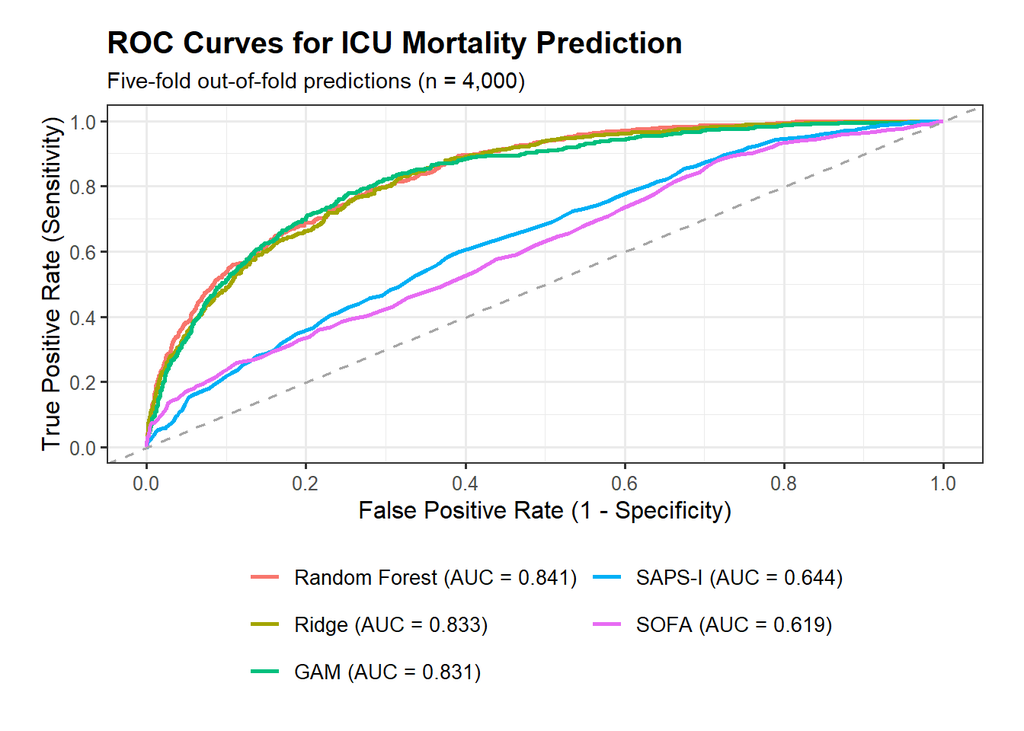

```r
# ============================================================
# 2.7.6 Improved ROC plot
# ============================================================

library(ggplot2)
library(dplyr)
library(yardstick)

# ROC coordinates from out-of-fold predictions
roc_data <- all_oof |>
  group_by(Model) |>
  roc_curve(
    truth = truth,
    p_death,
    event_level = "second"
  ) |>
  ungroup()

# Legend labels
auc_labels <- comparison_table |>
  mutate(
    Legend = paste0(
      as.character(Model),
      " (AUC = ",
      sprintf("%.3f", Pooled_AUROC),
      ")"
    )
  )

label_map <- setNames(
  auc_labels$Legend,
  as.character(auc_labels$Model)
)

roc_data <- roc_data |>
  mutate(
    Model_label = factor(
      label_map[as.character(Model)],
      levels = unname(label_map[model_order])
    )
  )

# Improved plot
roc_plot <- ggplot(
  roc_data,
  aes(
    x = 1 - specificity,
    y = sensitivity,
    color = Model_label,
    group = Model_label
  )
) +
  geom_path(linewidth = 1.05) +
  geom_abline(
    intercept = 0,
    slope = 1,
    linetype = "dashed",
    color = "gray65"
  ) +
  scale_x_continuous(
    limits = c(0, 1),
    breaks = seq(0, 1, 0.2)
  ) +
  scale_y_continuous(
    limits = c(0, 1),
    breaks = seq(0, 1, 0.2)
  ) +
  labs(
    title = "ROC Curves for ICU Mortality Prediction",
    subtitle = "Five-fold out-of-fold predictions (n = 4,000)",
    x = "False Positive Rate (1 - Specificity)",
    y = "True Positive Rate (Sensitivity)",
    color = "Model"
  ) +
  theme_bw(base_size = 12) +
  theme(
    plot.title = element_text(
      face = "bold",
      size = 15
    ),
    plot.subtitle = element_text(size = 11),
    legend.position = "bottom",
    legend.title = element_blank(),
    legend.text = element_text(size = 10),
    plot.margin = margin(15, 20, 15, 20)
  ) +
  guides(
    color = guide_legend(ncol = 2)
  )

# Display
print(roc_plot)
```

```r
# Save publication-style figure
ggsave(
  "output/cp2_roc_all_models.png",
  plot = roc_plot,
  width = 10,
  height = 7,
  units = "in",
  dpi = 300,
  bg = "white"
)
```

**Figure interpretation.** The three fitted machine-learning models have very similar ROC curves and clearly outperform the two clinical-score benchmarks over much of the false-positive-rate range. The figure legend reports *pooled* OOF AUROCs, while the comparison table reports the primary mean and SD of five held-out fold AUROCs. The two summaries need not be numerically identical.

### 2.7.7 Final model selection

```r
# ============================================================
# Final model selection
# ============================================================

best_model_name <- comparison_table |>
  arrange(desc(Mean_AUROC)) |>
  slice(1) |>
  pull(Model) |>
  as.character()

cat("Selected final model:", best_model_name, "\n")
```

```
Selected final model: Random Forest
```

```r
# Confirm the selected model
stopifnot(
  best_model_name == "Random Forest"
)

# Save the already refitted RF workflow if it exists
if (exists("rf_final_fit", inherits = TRUE)) {

  saveRDS(
    rf_final_fit,
    "output/cp2_final_model.rds"
  )

  cat("Final Random Forest model saved.\n")

} else if (file.exists(
  "output/cp2_model3_rf.rds"
)) {

  file.copy(
    "output/cp2_model3_rf.rds",
    "output/cp2_final_model.rds",
    overwrite = TRUE
  )

  cat("Saved RF model copied to final model file.\n")

} else {
  stop("Final RF model not found: check Section 2.6 outputs")
}
```

```
Final Random Forest model saved.
```

### 2.7.8 Output verification

```r
# ============================================================
# Final output validation
# ============================================================

required_files <- c(
  "output/cp2_all_fold_performance.csv",
  "output/cp2_model_comparison.csv",
  "output/cp2_oof_predictions.csv",
  "output/cp2_roc_all_models.png",
  "output/cp2_final_model.rds"
)

output_check <- tibble(
  File = required_files,
  Exists = file.exists(required_files)
)

knitr::kable(
  output_check,
  caption = "Checkpoint 2 final output verification"
)
```

Checkpoint 2 final output verification

| File | Exists |
| --- | --- |
| output/cp2_all_fold_performance.csv | TRUE |
| output/cp2_model_comparison.csv | TRUE |
| output/cp2_oof_predictions.csv | TRUE |
| output/cp2_roc_all_models.png | TRUE |
| output/cp2_final_model.rds | TRUE |

```r
if (all(output_check$Exists)) {

  cat(
    "\nSUCCESS: All required Section 2.7 files exist.\n"
  )

} else {

  cat(
    "\nSome files are missing. ",
    "Check the output table above.\n"
  )
}
```

```
SUCCESS: All required Section 2.7 files exist.
```

### Conclusion and limitations

Random forest is selected because it has the best mean held-out AUROC and mean Brier score across the compared methods, while retaining a reasonably small variation across folds. The advantage over ridge and GAM is modest and does not establish statistical superiority. Ridge is simpler and its standardized coefficients are more directly interpretable; GAM helps visualize nonlinearity. The benchmark scores have substantially worse discrimination in this particular dataset. All estimates are internal to set-a. They do not establish clinical utility or generalization to another hospital, population or period. Follow-up work should evaluate calibration, decision curves and subgroups, which are deferred to Checkpoint 3.

### Reproducibility and outputs

Only relative paths are used. All results come from the set-a patient files and `Outcomes-a.txt`; random seeds and common CV folds are defined above. The fitted preprocessing and final random forest are saved as `output/cp2_final_model.rds`, alongside `output/cp2_oof_predictions.csv`, figure files and the fold-level model comparison. Generate this report from a fresh repository checkout using `pixi run --locked checkpoint2` once the environment and data are in place. The command should produce `output/checkpoint2.html`.